# netflix_original_로버스트회귀

## 데이터 정의(성공,실패군집)

```r
rm(list=ls())

library(readxl) # readxl 패키지로 엑셀을 읽을 수 있게 해줌
netflix <- read_excel('netflix_original_종합_수정(sum)_(정량화보함).xlsx') # 넷플릭스 오리지널 엑셀데이터를 읽어옴
```

```
* `` -> ...1
```

결과값의 차이를 확인해 보기 위해 종합데이터, 드라마 데이터, 영화 데이터의 회귀를 각각 돌려보았습니다

### 종합 데이터

```r
netflix_original <- netflix
netflix_original <- netflix_original[,c(9,15,18,32:40)] # 엑셀에서 9,15,18 과 32~40번째 열을 가져오는 것.
netflix_original <- na.omit(netflix_original) # 어떤 결측치라도 있으면 행을 제거하고 남은 데이터를 반환
netflix_original[, 4:12] <- lapply(netflix_original[, 4:12], factor) # 위에서 뽑은 12개 열중 4~12열을 계산을 편하게 만들어주고 factor 형태로 만들어줌
netflix_original[, 1:3] <- lapply(netflix_original[, 1:3], as.numeric) # Mean_Length, Director_max_award, All_rating (1~3열) 항목을 숫자형으로 변환
```

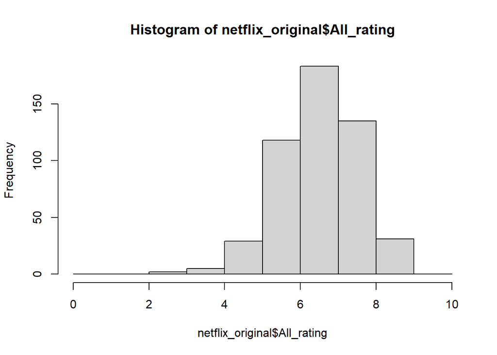

```r
hist(netflix_original$All_rating, seq(0,10)) # 6 점을 기준으로 성공 실패 자름
```

```r
median(netflix_original$All_rating)
```

```
[1] 6.5
```

```r
quantile(as.integer(netflix_original$All_rating))
```

```
  0%  25%  50%  75% 100%
   2    5    6    7    8
```

```r
# 성공 실패 나누기
netflix_original_success <- netflix_original[netflix_original$All_rating>=6.5,]
netflix_original_failure <- netflix_original[netflix_original$All_rating<6.5,]
```

### 드라마 데이터

드라마 데이터와 영화 데이터도 위와 같은 방식인데, 행의 차이만 있음.

드라마와 영화데이터를 나눈 기준은 seasons 항목이 공백이면 영화, 값이 있으면 드라마로 분류하여 분석하였음.

```r
netflix_drama <- netflix[1:170,]
netflix_drama <- netflix_drama[,c(9,15,18,32:40)]
netflix_drama <- na.omit(netflix_drama)
netflix_drama[, 4:12] <- lapply(netflix_drama[, 4:12], factor)
netflix_drama[, 1:3] <- lapply(netflix_drama[, 1:3], as.numeric)
```

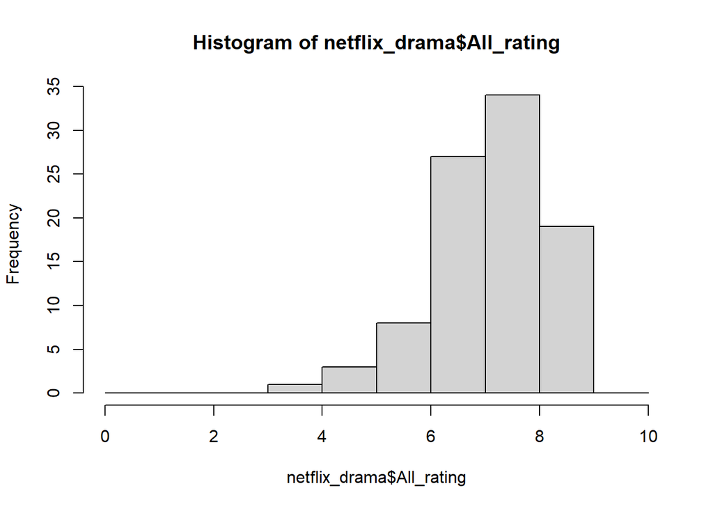

```r
hist(netflix_drama$All_rating, seq(0,10)) # 7점을 기준으로 성공 실패 자름
```

```r
median(netflix_drama$All_rating)
```

```
[1] 7.35
```

```r
quantile(as.integer(netflix_drama$All_rating))
```

```
  0%  25%  50%  75% 100%
3.00 6.00 7.00 7.25 8.00
```

```r
# 성공 실패 나누기
netflix_drama_success <- netflix_drama[netflix_drama$All_rating>=7.35,]
netflix_drama_failure <- netflix_drama[netflix_drama$All_rating<7.35,]
```

### 영화 데이터

```r
netflix_movie <- netflix[171:589,]
netflix_movie <- netflix_movie[,c(9,15,18,32:40)]
netflix_movie <- na.omit(netflix_movie)
netflix_movie[, 4:12] <- lapply(netflix_movie[, 4:12], factor)
netflix_movie[, 1:3] <- lapply(netflix_movie[, 1:3], as.numeric)
```

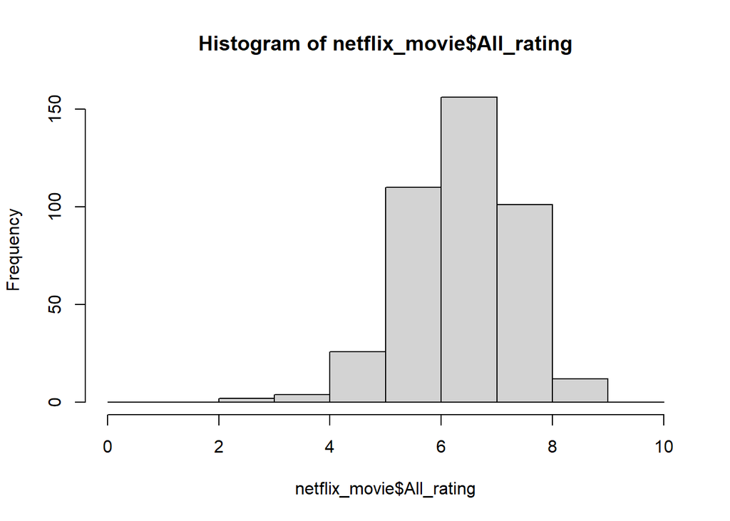

```r
hist(netflix_movie$All_rating, seq(0,10)) # 6점을 기준으로 성공 실패 자름
```

```r
median(netflix_movie$All_rating)
```

```
[1] 6.4
```

```r
quantile(as.integer(netflix_movie$All_rating))
```

```
  0%  25%  50%  75% 100%
   2    5    6    7    8
```

```r
# 성공 실패 나누기
netflix_movie_success <- netflix_movie[netflix_movie$All_rating>=6.4,]
netflix_movie_failure <- netflix_movie[netflix_movie$All_rating<6.4,]
```

## 데이터 시각화

ggplot2 는 데이터를 시각화하기 위한 패키지

넷플릭스 오리지널을 데이터로 사용하고 미학요소인 aes로 x축을 년도, y축을 전체평점으로 정의한다

geom_boxplot을 이용하여 박스그래프 그림

outlier.colour = ‘red’ 로 이상치의 색상을 빨간색으로 표현되게 하였다.

xlab: x축 제목, ylab: y축제목, labs: 범례

위의 방식으로 처음 선정한 factor(제작년도, 관람등급, 유해한주제(정도), 선정성, 폭력성, profanity(욕설), 무서움, 마약, Immatatable)를 x축으로 평점을 y축으로 하여 박스플롯형태로 시각화 한다.

### 년도

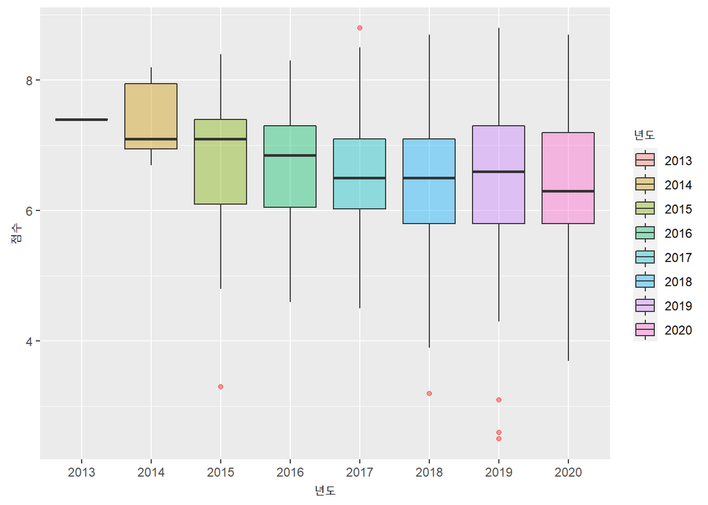

```r
library(ggplot2)
ggplot(netflix_original,aes(x=as.factor(Year),y=All_rating))+
  geom_boxplot(aes(fill=as.factor(Year)),outlier.colour = 'red',alpha=I(0.4))+
  xlab("년도") + ylab("점수") + labs(fill = "년도")
```

### Age

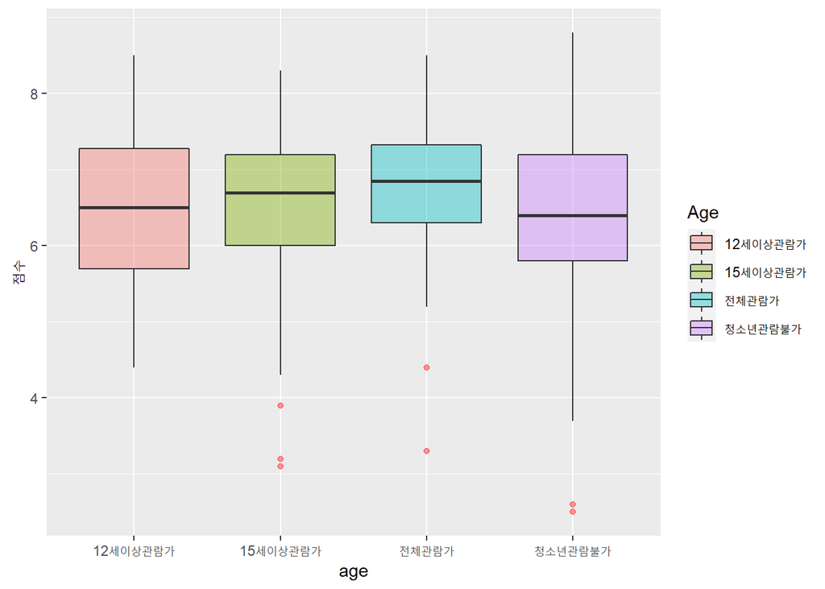

```r
ggplot(netflix_original,aes(x=as.factor(Age),y=All_rating))+
  geom_boxplot(aes(fill=as.factor(Age)),outlier.colour = 'red',alpha=I(0.4))+
  xlab("age") + ylab("점수") + labs(fill = "Age")
```

### Harmful_themes

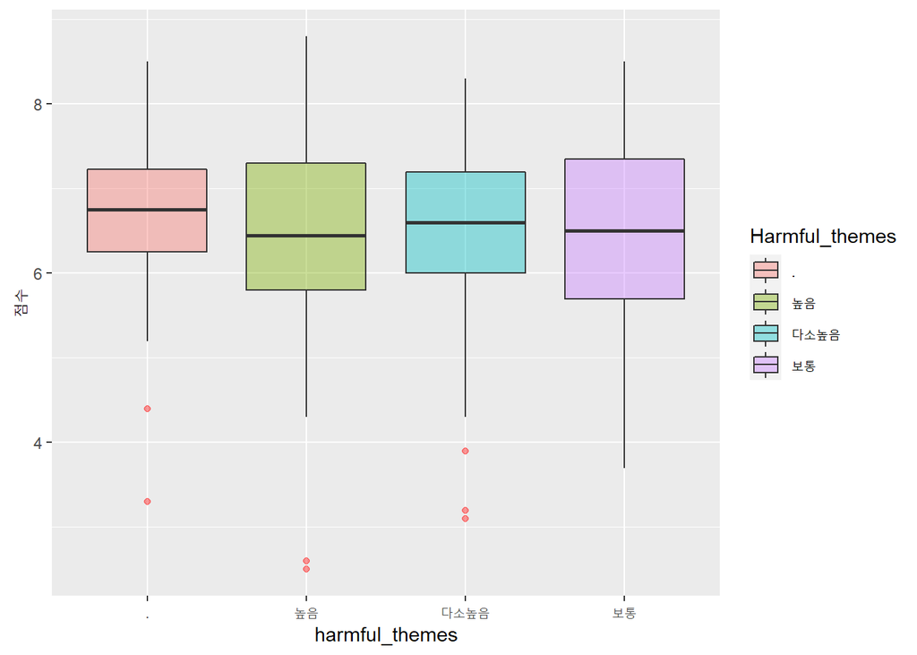

```r
ggplot(netflix_original,aes(x=as.factor(Harmful_themes),y=All_rating))+
  geom_boxplot(aes(fill=as.factor(Harmful_themes)),outlier.colour = 'red',alpha=I(0.4))+
  xlab("harmful_themes") + ylab("점수") + labs(fill = "Harmful_themes")
```

### Lewdness

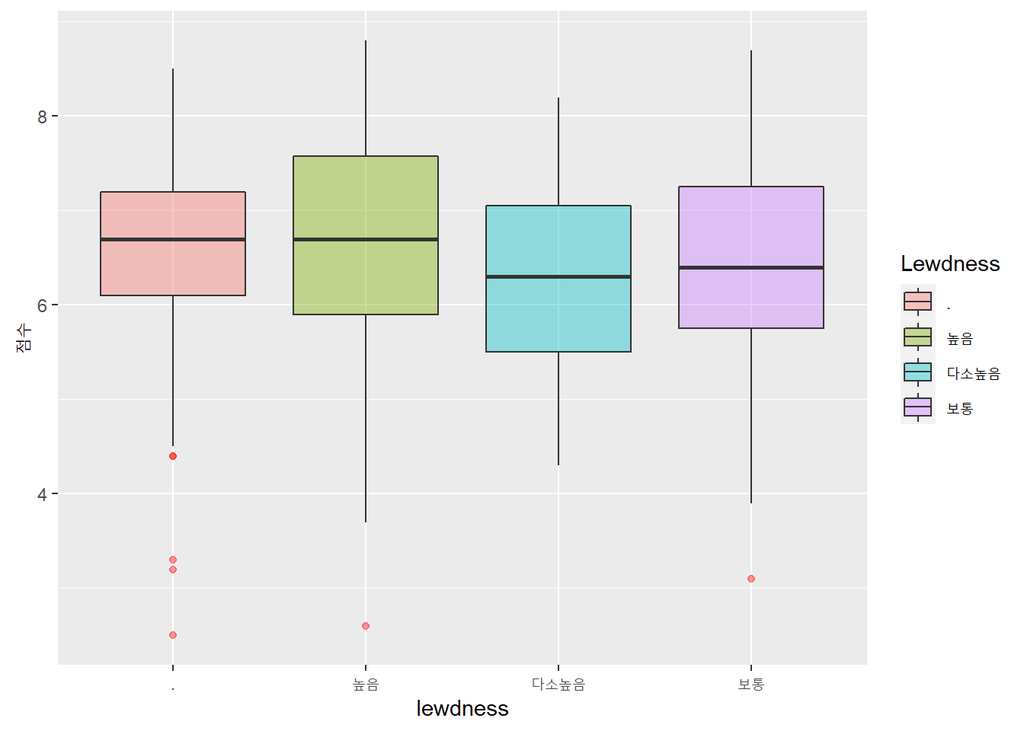

```r
ggplot(netflix_original,aes(x=as.factor(Lewdness),y=All_rating))+
  geom_boxplot(aes(fill=as.factor(Lewdness)),outlier.colour = 'red',alpha=I(0.4))+
  xlab("lewdness") + ylab("점수") + labs(fill = "Lewdness")
```

### Violence

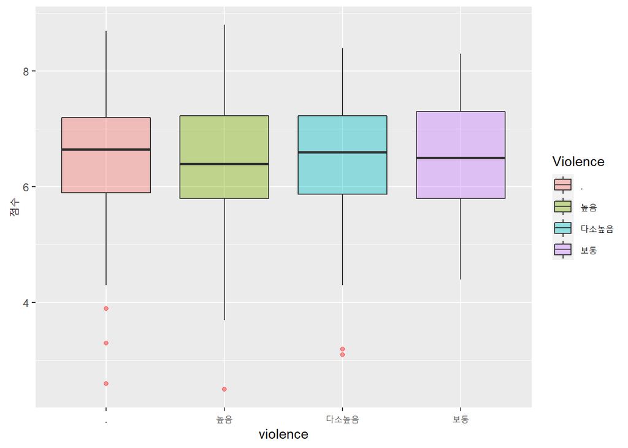

```r
ggplot(netflix_original,aes(x=as.factor(Violence),y=All_rating))+
  geom_boxplot(aes(fill=as.factor(Violence)),outlier.colour = 'red',alpha=I(0.4))+
  xlab("violence") + ylab("점수") + labs(fill = "Violence")
```

### Profanity

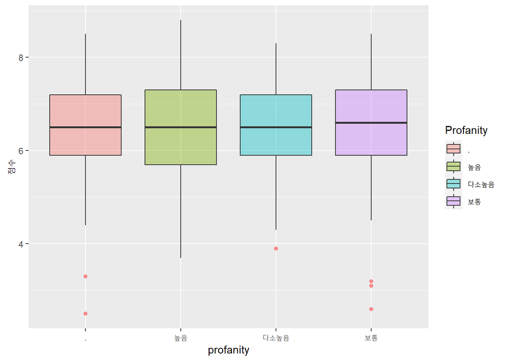

```r
ggplot(netflix_original,aes(x=as.factor(Profanity),y=All_rating))+
  geom_boxplot(aes(fill=as.factor(Profanity)),outlier.colour = 'red',alpha=I(0.4))+
  xlab("profanity") + ylab("점수") + labs(fill = "Profanity")
```

### Fear

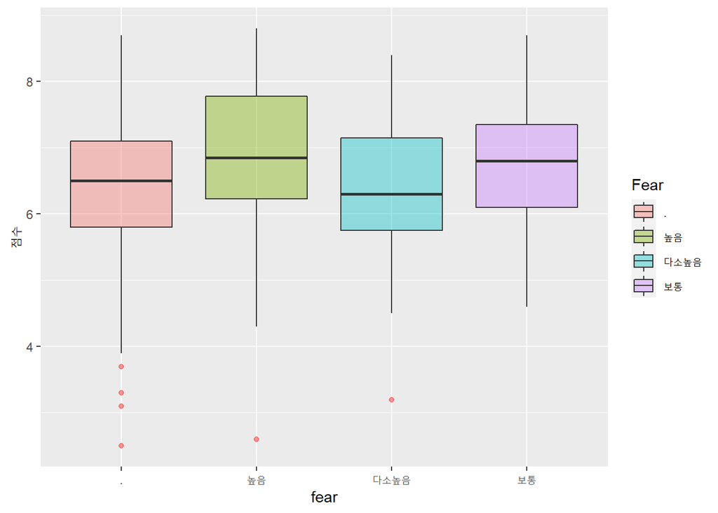

```r
ggplot(netflix_original,aes(x=as.factor(Fear),y=All_rating))+
  geom_boxplot(aes(fill=as.factor(Fear)),outlier.colour = 'red',alpha=I(0.4))+
  xlab("fear") + ylab("점수") + labs(fill = "Fear")
```

### Drugs

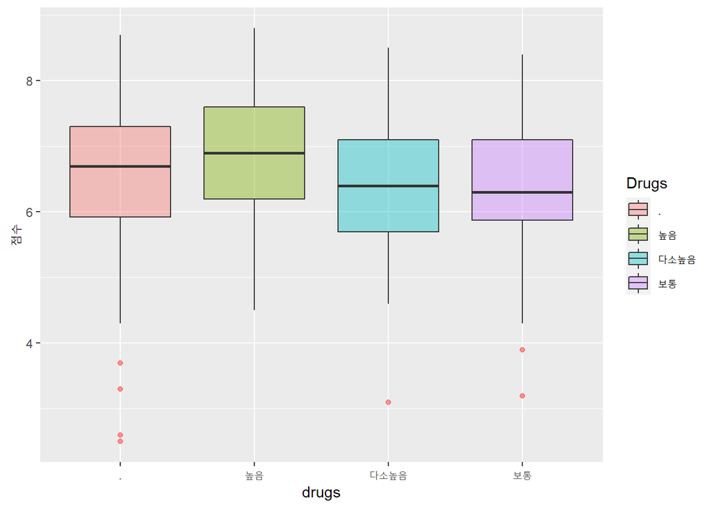

```r
ggplot(netflix_original,aes(x=as.factor(Drugs),y=All_rating))+
  geom_boxplot(aes(fill=as.factor(Drugs)),outlier.colour = 'red',alpha=I(0.4))+
  xlab("drugs") + ylab("점수") + labs(fill = "Drugs")
```

### Immatatable

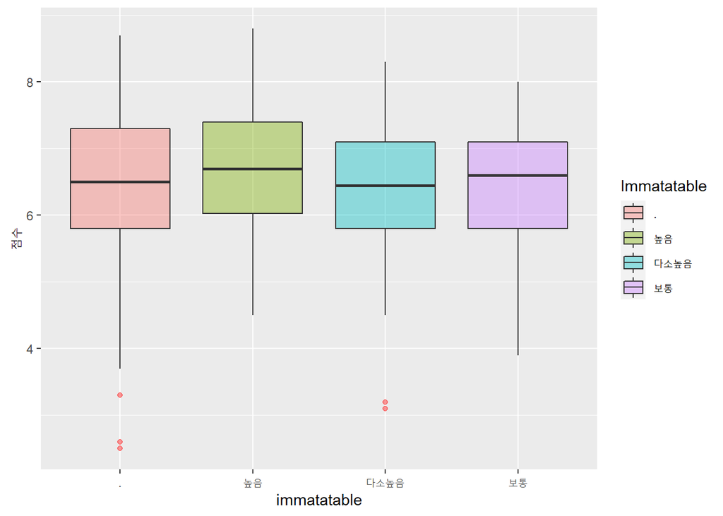

```r
ggplot(netflix_original,aes(x=as.factor(Immatatable),y=All_rating))+
  geom_boxplot(aes(fill=as.factor(Immatatable)),outlier.colour = 'red',alpha=I(0.4))+
  xlab("immatatable") + ylab("점수") + labs(fill = "Immatatable")
```

## 다중공선성확인(GVIF^(1/(2*Df)) > 2시 문제)

### 종합데이터

```r
library(car)
fit_tmp <- lm(All_rating ~ . , data=netflix_original_success)
vif(fit_tmp)
```

```
                         GVIF Df GVIF^(1/(2*Df))
Mean_Length          1.427529  1        1.194792
Director_max_award   1.230088  1        1.109093
Age                383.873740  3        2.695865
Year                 2.531004  7        1.068579
Harmful_themes     295.656843  3        2.581059
Lewdness             5.108169  3        1.312334
Violence             6.480512  3        1.365426
Profanity           17.344827  3        1.608897
Fear                 4.530605  3        1.286351
Drugs                6.881533  3        1.379159
Immatatable          8.323929  3        1.423600
```

```r
fit_tmp <- lm(All_rating ~ . , data=netflix_original_failure)
vif(fit_tmp)
```

```
                         GVIF Df GVIF^(1/(2*Df))
Mean_Length          1.355267  1        1.164159
Director_max_award   1.213570  1        1.101622
Age                129.761477  3        2.250044
Year                 2.695831  5        1.104255
Harmful_themes      76.098119  3        2.058554
Lewdness             3.449888  3        1.229233
Violence             5.011787  3        1.308174
Profanity            6.872884  3        1.378870
Fear                 3.235182  3        1.216139
Drugs                3.954753  3        1.257534
Immatatable          5.031876  3        1.309046
```

### 드라마데이터(there are aliased coefficients in the model)

```r
# fit_tmp <- lm(All_rating ~ . , data=netflix_drama_success)
# vif(fit_tmp)
```

```r
# fit_tmp <- lm(All_rating ~ . , data=netflix_drama_failure)
# vif(fit_tmp)
```

### 영화데이터

```r
fit_tmp <- lm(All_rating ~ . , data=netflix_movie_success)
vif(fit_tmp)
```

```
                         GVIF Df GVIF^(1/(2*Df))
Mean_Length          1.391212  1        1.179496
Director_max_award   1.239873  1        1.113496
Age                461.556814  3        2.779953
Year                 3.118443  7        1.084629
Harmful_themes     354.511823  3        2.660348
Lewdness             3.178569  3        1.212566
Violence             6.231797  3        1.356549
Profanity            8.870054  3        1.438758
Fear                 4.433844  3        1.281731
Drugs                4.220011  3        1.271215
Immatatable          6.098866  3        1.351683
```

```r
fit_tmp <- lm(All_rating ~ . , data=netflix_movie_failure)
vif(fit_tmp)
```

```
                        GVIF Df GVIF^(1/(2*Df))
Mean_Length         1.405809  1        1.185668
Director_max_award  1.299445  1        1.139932
Age                97.701766  3        2.146102
Year                3.344649  5        1.128327
Harmful_themes     59.446496  3        1.975549
Lewdness            3.584562  3        1.237103
Violence            5.348039  3        1.322409
Profanity           6.465236  3        1.364889
Fear                3.619452  3        1.239102
Drugs               4.096732  3        1.264949
Immatatable         5.438740  3        1.326121
```

Age와 Harmful_themes에서 다중공선성 존재 이후 분석에서 age제거

다중공선성 재확인

### 종합데이터

```r
netflix_original_success <- netflix_original_success[,c(-4,-6)] # Age, Harmful제거
fit_tmp <- lm(All_rating ~ . , data=netflix_original_success)
vif(fit_tmp)
```

```
                       GVIF Df GVIF^(1/(2*Df))
Mean_Length        1.339223  1        1.157248
Director_max_award 1.196108  1        1.093667
Year               2.182383  7        1.057327
Lewdness           4.731550  3        1.295688
Violence           5.432862  3        1.325882
Profanity          7.654873  3        1.403857
Fear               4.211271  3        1.270776
Drugs              6.124941  3        1.352644
Immatatable        7.443444  3        1.397319
```

```r
netflix_original_failure <- netflix_original_failure[,c(-4,-6)] # Age, Harmful제거
fit_tmp <- lm(All_rating ~ . , data=netflix_original_failure)
vif(fit_tmp)
```

```
                       GVIF Df GVIF^(1/(2*Df))
Mean_Length        1.236547  1        1.112001
Director_max_award 1.152260  1        1.073434
Year               2.257110  5        1.084814
Lewdness           2.528227  3        1.167175
Violence           3.764798  3        1.247260
Profanity          3.627334  3        1.239552
Fear               3.037981  3        1.203458
Drugs              3.165265  3        1.211718
Immatatable        4.409093  3        1.280535
```

### 드라마데이터

```r
netflix_drama_success <- netflix_drama_success[,c(-4,-6)] # Age, Harmful제거
fit_tmp <- lm(All_rating ~ . , data=netflix_drama_success)
vif(fit_tmp)
```

```
                          GVIF Df GVIF^(1/(2*Df))
Mean_Length           1.915795  1        1.384123
Director_max_award    1.647572  1        1.283578
Year                 95.925057  5        1.578313
Lewdness            168.500452  3        2.350175
Violence             58.681416  3        1.971288
Profanity          1374.078143  3        3.334279
Fear                 29.983472  3        1.762572
Drugs               693.399887  3        2.975071
Immatatable         213.494345  3        2.444731
```

```r
netflix_drama_failure <- netflix_drama_failure[,c(-4,-6)] # Age, Harmful제거
fit_tmp <- lm(All_rating ~ . , data=netflix_drama_failure)
vif(fit_tmp)
```

```
                         GVIF Df GVIF^(1/(2*Df))
Mean_Length          3.011237  1        1.735292
Director_max_award   1.711084  1        1.308084
Year                 8.320210  4        1.303217
Lewdness           117.717214  3        2.213808
Violence            18.800954  3        1.630660
Profanity           94.137150  3        2.132849
Fear                21.536714  3        1.668002
Drugs               70.527631  3        2.032637
Immatatable         45.908321  3        1.892265
```

### 영화데이터

```r
netflix_movie_success <- netflix_movie_success[,c(-4,-6)] # Age, Harmful제거
fit_tmp <- lm(All_rating ~ . , data=netflix_movie_success)
vif(fit_tmp)
```

```
                       GVIF Df GVIF^(1/(2*Df))
Mean_Length        1.347019  1        1.160612
Director_max_award 1.218532  1        1.103871
Year               2.494964  7        1.067485
Lewdness           2.619869  3        1.174122
Violence           4.446757  3        1.282352
Profanity          4.163030  3        1.268338
Fear               3.814603  3        1.249995
Drugs              3.634488  3        1.239959
Immatatable        4.844021  3        1.300771
```

```r
netflix_movie_failure <- netflix_movie_failure[,c(-4,-6)] # Age, Harmful제거
fit_tmp <- lm(All_rating ~ . , data=netflix_movie_failure)
vif(fit_tmp)
```

```
                       GVIF Df GVIF^(1/(2*Df))
Mean_Length        1.283602  1        1.132961
Director_max_award 1.226645  1        1.107540
Year               2.767300  5        1.107148
Lewdness           2.551918  3        1.168991
Violence           3.822610  3        1.250432
Profanity          3.384312  3        1.225307
Fear               3.335205  3        1.222326
Drugs              3.004968  3        1.201268
Immatatable        4.748369  3        1.296455
```

## Cooks distance outlier제거

종합데이터, 드라마데이터, 영화데이터를 가지고 outlier(이상치)를 제거하는 기준으로 cooks distance를 사용하였다.

### 종합 데이터

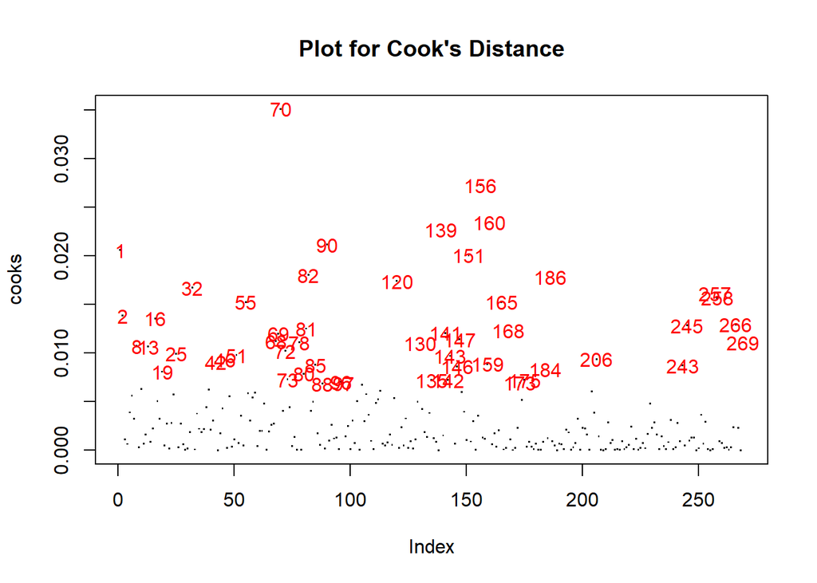

```r
fit_tmp <- lm(All_rating ~ . , data=netflix_original_success) #lm :  linear regression의 핵심으로, 회귀분석, 단일 계층 분석, 공분산 분석에 이용할 수 있다.
cooks <- cooks.distance(fit_tmp) # 일반회귀를 통해 cooks 값을 구한다.
plot(cooks, pch=".", cex=1.5, main = "Plot for Cook's Distance") # cooks 시각화
# plot() 함수는 x, y 인자 2개를 기본적으로 받습니다.
# cex : 기호의 크기를 지정할 때 사용 cex에 입력하는 숫자는 디폴트인 cex=1 대비 상대적인 크기를 나타냄.

text(x=1:length(cooks), y=cooks, labels = ifelse(cooks > 4/nrow(netflix), names(cooks), ""), col = "red") # 어떤 데이터인지 plot에 표시
```

```r
outlier <- names(cooks)[(cooks > 4/nrow(netflix_original_success))] # outlier기준: 4/(sample size)를 넘는 cooks값을 가진 데이터
outlier <- as.integer(na.omit(outlier))
netflix_original_success <- netflix_original_success[-outlier, ] # oulier로 판정된 데이터 제거
```

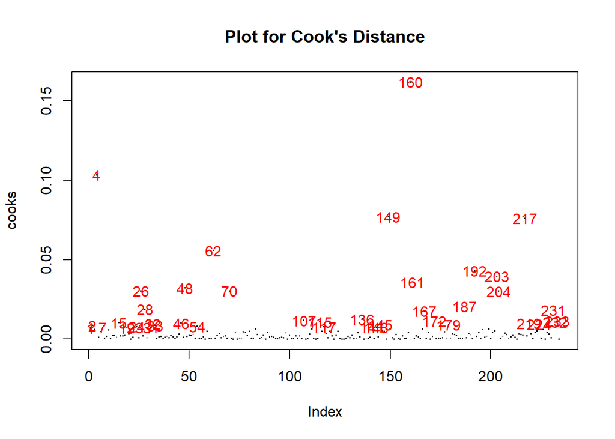

```r
fit_tmp <- lm(All_rating ~ . , data=netflix_original_failure)
cooks <- cooks.distance(fit_tmp)
plot(cooks, pch=".", cex=1.5, main = "Plot for Cook's Distance")

text(x=1:length(cooks), y=cooks, labels = ifelse(cooks > 4/nrow(netflix), names(cooks), ""), col = "red")
```

```r
outlier <- names(cooks)[(cooks > 4/nrow(netflix_original_failure))]
outlier <- as.integer(na.omit(outlier))
netflix_original_failure <- netflix_original_failure[-outlier, ]
```

### 드라마 데이터

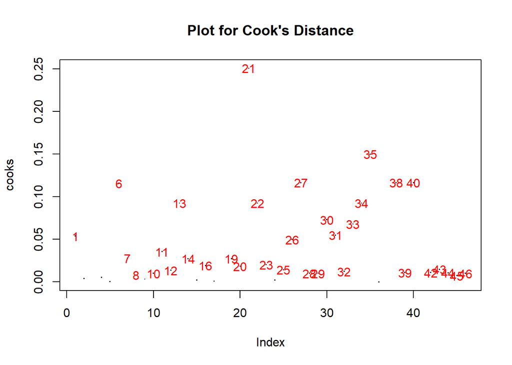

```r
fit_tmp <- lm(All_rating ~ . , data=netflix_drama_success)
cooks <- cooks.distance(fit_tmp)
plot(cooks, pch=".", cex=1.5, main = "Plot for Cook's Distance")

text(x=1:length(cooks), y=cooks, labels = ifelse(cooks > 4/nrow(netflix), names(cooks), ""), col = "red")
```

```r
outlier <- names(cooks)[(cooks > 4/nrow(netflix_drama_success))]
outlier <- as.integer(na.omit(outlier))
netflix_drama_success <- netflix_drama_success[-outlier, ]
```

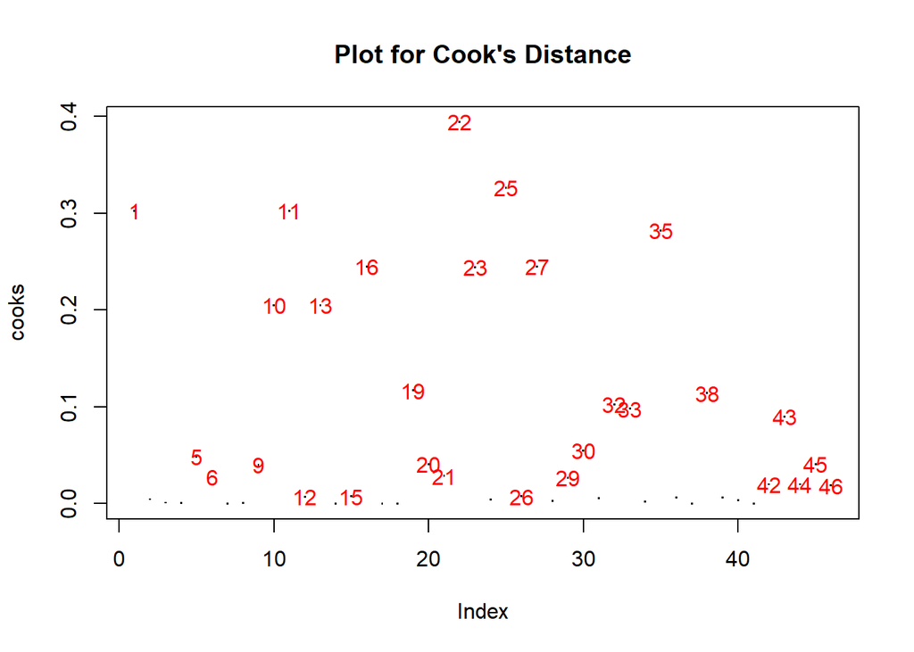

```r
fit_tmp <- lm(All_rating ~ . , data=netflix_drama_failure)
cooks <- cooks.distance(fit_tmp)
plot(cooks, pch=".", cex=1.5, main = "Plot for Cook's Distance")

text(x=1:length(cooks), y=cooks, labels = ifelse(cooks > 4/nrow(netflix), names(cooks), ""), col = "red")
```

```r
outlier <- names(cooks)[(cooks > 4/nrow(netflix_drama_failure))]
outlier <- as.integer(na.omit(outlier))
netflix_drama_failure <- netflix_drama_failure[-outlier, ]
```

### 영화 데이터

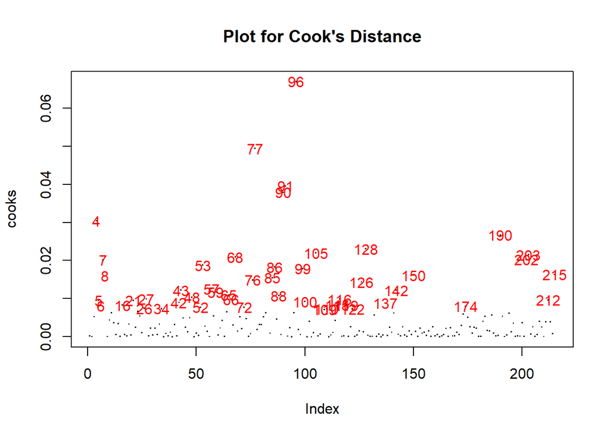

```r
fit_tmp <- lm(All_rating ~ . , data=netflix_movie_success)
cooks <- cooks.distance(fit_tmp)
plot(cooks, pch=".", cex=1.5, main = "Plot for Cook's Distance")

text(x=1:length(cooks), y=cooks, labels = ifelse(cooks > 4/nrow(netflix), names(cooks), ""), col = "red")
```

```r
outlier <- names(cooks)[(cooks > 4/nrow(netflix_movie_success))]
outlier <- as.integer(na.omit(outlier))
netflix_movie_success <- netflix_movie_success[-outlier, ]
```

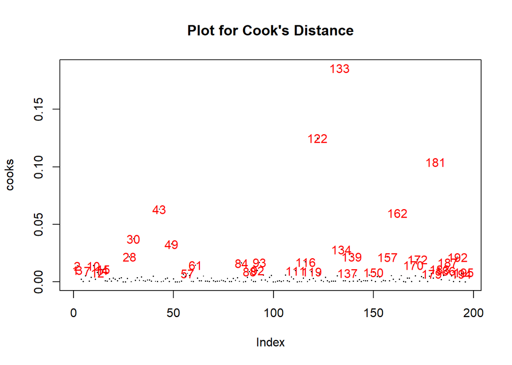

```r
fit_tmp <- lm(All_rating ~ . , data=netflix_movie_failure)
cooks <- cooks.distance(fit_tmp)
plot(cooks, pch=".", cex=1.5, main = "Plot for Cook's Distance")

text(x=1:length(cooks), y=cooks, labels = ifelse(cooks > 4/nrow(netflix), names(cooks), ""), col = "red")
```

```r
outlier <- names(cooks)[(cooks > 4/nrow(netflix_movie_failure))]
outlier <- as.integer(na.omit(outlier))
netflix_movie_failure <- netflix_movie_failure[-outlier, ]
```

## 일반회귀

### 종합 데이터(성공)

#### 세부 factor에서 유의한 값

Estimate , Std. Error, t value, Pr(>|t|) 를 확인하고, 유의미한 정도를 *의 개수를 통해 확인할 수 있다.

```r
fit_OLS_original_success <- lm(All_rating ~ . , data=netflix_original_success)
summary(fit_OLS_original_success) # Summary() 함수는 중심화 경향과 퍼짐정도에 대해서 quick 하게 볼 수 있는 통계량들을 제공합니다.
```

```
Call:
lm(formula = All_rating ~ ., data = netflix_original_success)

Residuals:
     Min       1Q   Median       3Q      Max
-1.02304 -0.33860 -0.05501  0.28131  1.26466

Coefficients:
                      Estimate Std. Error t value Pr(>|t|)
(Intercept)          7.4755498  0.5094164  14.675   <2e-16 ***
Mean_Length         -0.0009142  0.0010044  -0.910   0.3637
Director_max_award   0.0018690  0.0012585   1.485   0.1389
Year2014             0.0351031  0.5526488   0.064   0.9494
Year2015            -0.1832311  0.5504546  -0.333   0.7395
Year2016            -0.0368710  0.5262535  -0.070   0.9442
Year2017            -0.1716076  0.5142778  -0.334   0.7389
Year2018            -0.3299716  0.5103938  -0.647   0.5186
Year2019            -0.2240232  0.5096373  -0.440   0.6607
Year2020            -0.1939317  0.5140205  -0.377   0.7063
Lewdness높음         0.3132832  0.1392095   2.250   0.0254 *
Lewdness다소높음     0.0217028  0.1058807   0.205   0.8378
Lewdness보통         0.1014745  0.1155863   0.878   0.3809
Violence높음        -0.0252846  0.1502930  -0.168   0.8665
Violence다소높음    -0.0304320  0.1061744  -0.287   0.7747
Violence보통         0.0071597  0.1050062   0.068   0.9457
Profanity높음       -0.1687098  0.1723730  -0.979   0.3288
Profanity다소높음    0.0314350  0.1276564   0.246   0.8057
Profanity보통        0.0314221  0.1129090   0.278   0.7810
Fear높음             0.3254539  0.1510491   2.155   0.0322 *
Fear다소높음         0.1042080  0.1197096   0.871   0.3849
Fear보통             0.0365332  0.0970492   0.376   0.7069
Drugs높음            0.1981926  0.1559592   1.271   0.2051
Drugs다소높음       -0.0458068  0.1139982  -0.402   0.6882
Drugs보통           -0.0730349  0.1038120  -0.704   0.4824
Immatatable높음     -0.1307370  0.1584829  -0.825   0.4103
Immatatable다소높음 -0.2085851  0.1043164  -2.000   0.0467 *
Immatatable보통     -0.1211513  0.1125566  -1.076   0.2829
---
Signif. codes:  0 '***' 0.001 '**' 0.01 '*' 0.05 '.' 0.1 ' ' 1

Residual standard error: 0.4998 on 226 degrees of freedom
Multiple R-squared:  0.1667,    Adjusted R-squared:  0.06715
F-statistic: 1.675 on 27 and 226 DF,  p-value: 0.02362
```

#### 유의한 factor

ANOVA는 하나 이상의 범주 형 독립 변수 수준에 따라 양적 종속 변수 가 어떻게 변하는 지 추정하기위한 통계 검정 입니다.

ANOVA 는 독립 변수의 각 수준에서 그룹 평균 에 차이가 있는지 여부를 테스트합니다. 변량 분석. 3개이상 다수 집단을 비교할 때 사용하는 가설검정 방법으로, 다수간의 평균 비교에서 ANOVA를 통해 유의한 차이를 검정

```r
anova(fit_OLS_original_success) # 유의한 factor를 확인하기 위해 ANOVA함수를 이용함
```

```
Analysis of Variance Table

Response: All_rating
                    Df Sum Sq Mean Sq F value   Pr(>F)
Mean_Length          1  0.477 0.47679  1.9085 0.168490
Director_max_award   1  0.518 0.51778  2.0726 0.151350
Year                 7  1.032 0.14737  0.5899 0.763856
Lewdness             3  3.899 1.29980  5.2029 0.001712 **
Violence             3  1.021 0.34038  1.3625 0.255068
Profanity            3  0.236 0.07877  0.3153 0.814307
Fear                 3  1.911 0.63717  2.5505 0.056505 .
Drugs                3  1.164 0.38809  1.5535 0.201560
Immatatable          3  1.036 0.34542  1.3826 0.248856
Residuals          226 56.460 0.24982
---
Signif. codes:  0 '***' 0.001 '**' 0.01 '*' 0.05 '.' 0.1 ' ' 1
```

#### 모델 유의성 확인

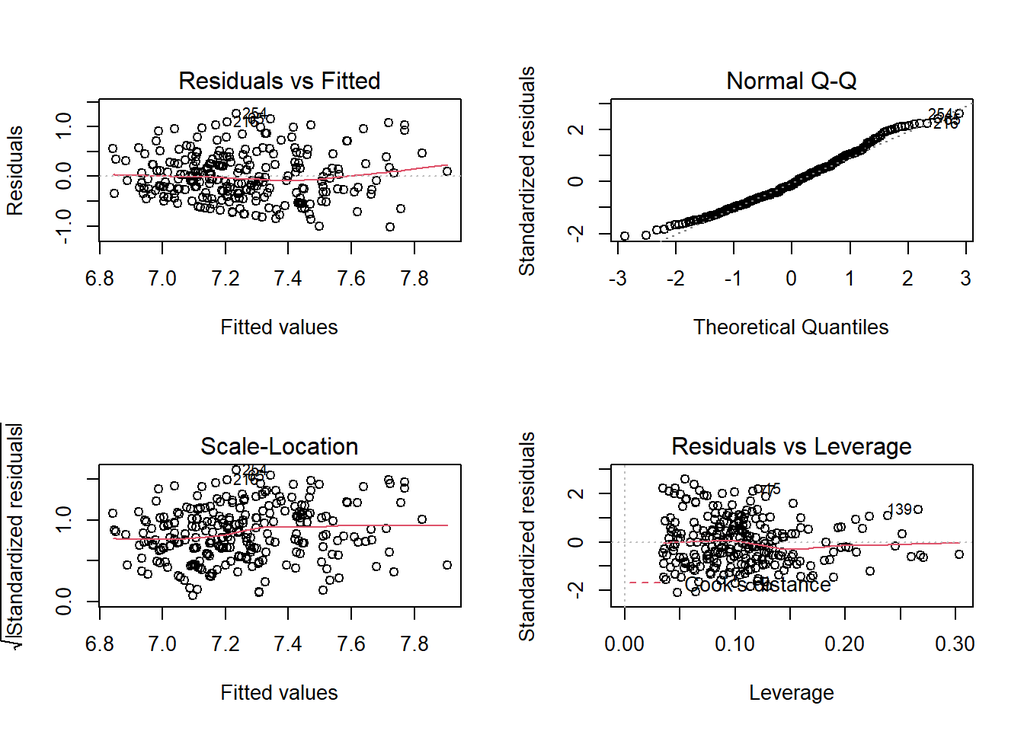

```r
par(mfrow = c(2,2)) # 한 화면에 여러 개의 그래프를 그려 비교하기 위해 par함수 사용
plot(fit_OLS_original_success) # fit_OLS_original의 그래프를 그려줌
```

### 종합 데이터(실패)

#### 세부 factor에서 유의한 값

```r
fit_OLS_original_failure <- lm(All_rating ~ . , data=netflix_original_failure)
summary(fit_OLS_original_failure)
```

```
Call:
lm(formula = All_rating ~ ., data = netflix_original_failure)

Residuals:
     Min       1Q   Median       3Q      Max
-1.25429 -0.24644  0.03596  0.34310  0.84195

Coefficients:
                     Estimate Std. Error t value Pr(>|t|)
(Intercept)          4.975559   0.425107  11.704   <2e-16 ***
Mean_Length          0.003409   0.001366   2.495   0.0134 *
Director_max_award   0.005664   0.003433   1.650   0.1006
Year2016             0.635885   0.422320   1.506   0.1338
Year2017             0.665537   0.404828   1.644   0.1018
Year2018             0.595217   0.403281   1.476   0.1416
Year2019             0.486225   0.403406   1.205   0.2296
Year2020             0.630689   0.405235   1.556   0.1213
Lewdness높음        -0.075526   0.128346  -0.588   0.5569
Lewdness다소높음    -0.258928   0.104084  -2.488   0.0137 *
Lewdness보통        -0.184267   0.108277  -1.702   0.0904 .
Violence높음        -0.120307   0.151105  -0.796   0.4269
Violence다소높음    -0.114801   0.115650  -0.993   0.3221
Violence보통        -0.129402   0.105635  -1.225   0.2221
Profanity높음       -0.157309   0.154163  -1.020   0.3088
Profanity다소높음    0.015112   0.138946   0.109   0.9135
Profanity보통       -0.057756   0.135872  -0.425   0.6713
Fear높음             0.269347   0.174012   1.548   0.1233
Fear다소높음        -0.071870   0.124694  -0.576   0.5650
Fear보통            -0.010291   0.120750  -0.085   0.9322
Drugs높음            0.184008   0.158545   1.161   0.2472
Drugs다소높음        0.041426   0.121860   0.340   0.7343
Drugs보통            0.141474   0.111834   1.265   0.2074
Immatatable높음      0.063432   0.147910   0.429   0.6685
Immatatable다소높음  0.028214   0.118882   0.237   0.8127
Immatatable보통     -0.066160   0.130445  -0.507   0.6126
---
Signif. codes:  0 '***' 0.001 '**' 0.01 '*' 0.05 '.' 0.1 ' ' 1

Residual standard error: 0.5062 on 192 degrees of freedom
Multiple R-squared:  0.1759,    Adjusted R-squared:  0.06855
F-statistic: 1.639 on 25 and 192 DF,  p-value: 0.03437
```

#### 유의한 factor

```r
anova(fit_OLS_original_failure)
```

```
Analysis of Variance Table

Response: All_rating
                    Df Sum Sq Mean Sq F value   Pr(>F)
Mean_Length          1  2.092 2.09185  8.1640 0.004744 **
Director_max_award   1  1.106 1.10616  4.3171 0.039061 *
Year                 5  1.966 0.39313  1.5343 0.180908
Lewdness             3  1.743 0.58116  2.2682 0.081955 .
Violence             3  0.727 0.24221  0.9453 0.419808
Profanity            3  0.494 0.16458  0.6423 0.588688
Fear                 3  1.283 0.42781  1.6696 0.174934
Drugs                3  0.930 0.31012  1.2103 0.307225
Immatatable          3  0.156 0.05215  0.2035 0.893859
Residuals          192 49.196 0.25623
---
Signif. codes:  0 '***' 0.001 '**' 0.01 '*' 0.05 '.' 0.1 ' ' 1
```

#### 모델 유의성 확인

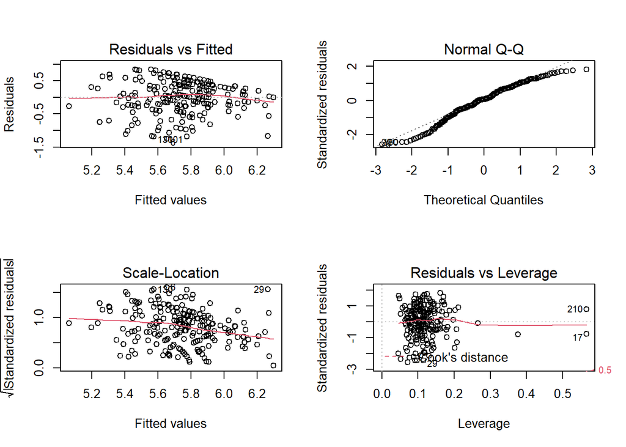

```r
par(mfrow = c(2,2)) # 한 화면에 여러 개의 그래프를 그려 비교하기 위해 par함수 사용
plot(fit_OLS_original_failure) # fit_OLS_original의 그래프를 그려줌
```

### 드라마 데이터(성공)

#### 세부 factor에서 유의한 값

```r
fit_OLS_drama_success <- lm(All_rating ~ . , data=netflix_drama_success)
summary(fit_OLS_drama_success)
```

```
Call:
lm(formula = All_rating ~ ., data = netflix_drama_success)

Residuals:
    Min      1Q  Median      3Q     Max
-0.4056 -0.1009  0.0000  0.1135  0.5070

Coefficients: (3 not defined because of singularities)
                     Estimate Std. Error t value Pr(>|t|)
(Intercept)          6.584172   0.787431   8.362 4.97e-07 ***
Mean_Length          0.002582   0.005042   0.512   0.6160
Director_max_award   0.011130   0.007004   1.589   0.1329
Year2016             0.747861   0.846584   0.883   0.3910
Year2017             1.388796   0.802181   1.731   0.1039
Year2018             1.502742   0.826502   1.818   0.0891 .
Year2019             0.926796   0.815513   1.136   0.2736
Year2020             1.195913   0.801308   1.492   0.1563
Lewdness높음        -1.075187   0.932871  -1.153   0.2671
Lewdness다소높음    -0.408435   0.469692  -0.870   0.3982
Lewdness보통        -0.133440   0.508028  -0.263   0.7964
Violence높음         0.919075   0.623340   1.474   0.1610
Violence다소높음     0.558309   0.518066   1.078   0.2982
Violence보통         0.629671   0.679240   0.927   0.3686
Profanity높음        0.656636   0.672429   0.977   0.3443
Profanity다소높음   -0.377516   0.679415  -0.556   0.5866
Profanity보통              NA         NA      NA       NA
Fear높음            -0.218120   0.529419  -0.412   0.6862
Fear다소높음        -0.599177   0.512620  -1.169   0.2607
Fear보통            -0.675334   0.581370  -1.162   0.2635
Drugs높음           -0.120415   0.504541  -0.239   0.8146
Drugs다소높음        0.360915   0.446081   0.809   0.4311
Drugs보통                  NA         NA      NA       NA
Immatatable높음      0.326689   0.316959   1.031   0.3190
Immatatable다소높음        NA         NA      NA       NA
---
Signif. codes:  0 '***' 0.001 '**' 0.01 '*' 0.05 '.' 0.1 ' ' 1

Residual standard error: 0.3192 on 15 degrees of freedom
Multiple R-squared:  0.7921,    Adjusted R-squared:  0.5009
F-statistic: 2.721 on 21 and 15 DF,  p-value: 0.02579
```

#### 유의한 factor

```r
anova(fit_OLS_drama_success)
```

```
Analysis of Variance Table

Response: All_rating
                   Df  Sum Sq Mean Sq F value  Pr(>F)
Mean_Length         1 0.14612 0.14612  1.4341 0.24967
Director_max_award  1 0.08022 0.08022  0.7873 0.38893
Year                5 2.20361 0.44072  4.3255 0.01229 *
Lewdness            3 0.83270 0.27757  2.7242 0.08111 .
Violence            3 1.10247 0.36749  3.6068 0.03845 *
Profanity           2 0.37453 0.18727  1.8379 0.19323
Fear                3 0.59066 0.19689  1.9324 0.16774
Drugs               2 0.38284 0.19142  1.8787 0.18702
Immatatable         1 0.10824 0.10824  1.0623 0.31902
Residuals          15 1.52833 0.10189
---
Signif. codes:  0 '***' 0.001 '**' 0.01 '*' 0.05 '.' 0.1 ' ' 1
```

#### 모델 유의성 확인

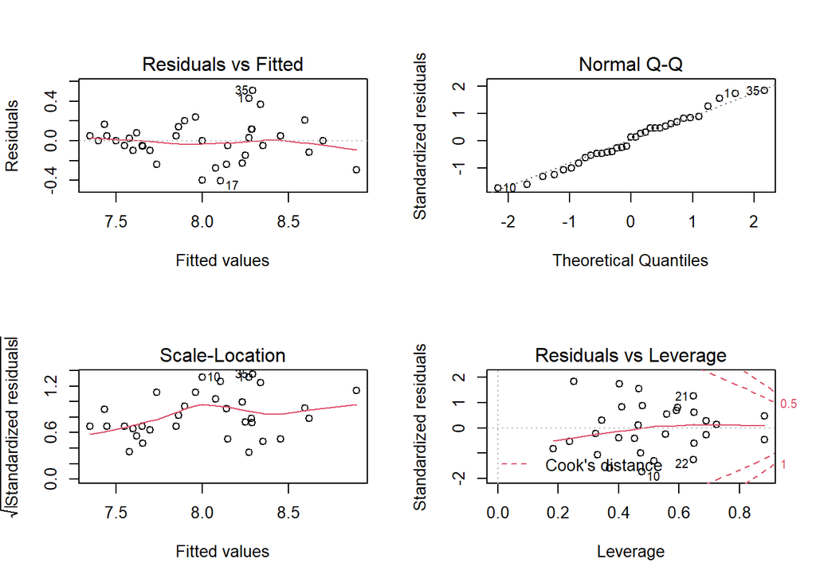

```r
par(mfrow = c(2,2))
plot(fit_OLS_drama_success)
```

### 드라마 데이터(실패)

#### 세부 factor에서 유의한 값

```r
fit_OLS_drama_failure <- lm(All_rating ~ . , data=netflix_drama_failure)
summary(fit_OLS_drama_failure)
```

```
Call:
lm(formula = All_rating ~ ., data = netflix_drama_failure)

Residuals:
     Min       1Q   Median       3Q      Max
-0.96338 -0.09507  0.00000  0.16581  0.46188

Coefficients: (1 not defined because of singularities)
                     Estimate Std. Error t value Pr(>|t|)
(Intercept)          5.958764   0.659082   9.041 8.23e-06 ***
Mean_Length         -0.004840   0.018506  -0.262    0.800
Director_max_award   0.009738   0.006549   1.487    0.171
Year2018            -0.476793   0.463097  -1.030    0.330
Year2019            -0.394554   0.401953  -0.982    0.352
Lewdness높음        -0.303216   1.427908  -0.212    0.837
Lewdness다소높음    -0.908555   1.503706  -0.604    0.561
Lewdness보통        -0.396977   0.716596  -0.554    0.593
Violence높음        -0.640275   0.804802  -0.796    0.447
Violence다소높음    -0.414453   0.589179  -0.703    0.500
Violence보통        -0.234664   0.500964  -0.468    0.651
Profanity높음        1.679317   1.291264   1.301    0.226
Profanity다소높음    1.817354   1.357620   1.339    0.214
Profanity보통        1.234241   0.608289   2.029    0.073 .
Fear높음             1.036939   0.796464   1.302    0.225
Fear다소높음         0.082851   0.615894   0.135    0.896
Fear보통             0.616891   0.651723   0.947    0.369
Drugs높음           -0.382036   0.843504  -0.453    0.661
Drugs다소높음        0.684214   0.768962   0.890    0.397
Drugs보통                  NA         NA      NA       NA
Immatatable높음      0.343995   0.717548   0.479    0.643
Immatatable다소높음 -0.168222   0.632281  -0.266    0.796
Immatatable보통      0.850368   0.914763   0.930    0.377
---
Signif. codes:  0 '***' 0.001 '**' 0.01 '*' 0.05 '.' 0.1 ' ' 1

Residual standard error: 0.4723 on 9 degrees of freedom
Multiple R-squared:  0.8383,    Adjusted R-squared:  0.461
F-statistic: 2.222 on 21 and 9 DF,  p-value: 0.1086
```

#### 유의한 factor

```r
anova(fit_OLS_drama_failure)
```

```
Analysis of Variance Table

Response: All_rating
                   Df Sum Sq Mean Sq F value  Pr(>F)
Mean_Length         1 0.3464 0.34643  1.5529 0.24416
Director_max_award  1 0.3604 0.36043  1.6157 0.23556
Year                2 0.5448 0.27241  1.2211 0.33946
Lewdness            3 3.7080 1.23602  5.5406 0.01969 *
Violence            3 1.4370 0.47900  2.1472 0.16429
Profanity           3 1.4775 0.49250  2.2077 0.15672
Fear                3 1.5213 0.50710  2.2732 0.14899
Drugs               2 0.3670 0.18349  0.8225 0.46981
Immatatable         3 0.6465 0.21551  0.9660 0.45006
Residuals           9 2.0077 0.22308
---
Signif. codes:  0 '***' 0.001 '**' 0.01 '*' 0.05 '.' 0.1 ' ' 1
```

#### 모델 유의성 확인

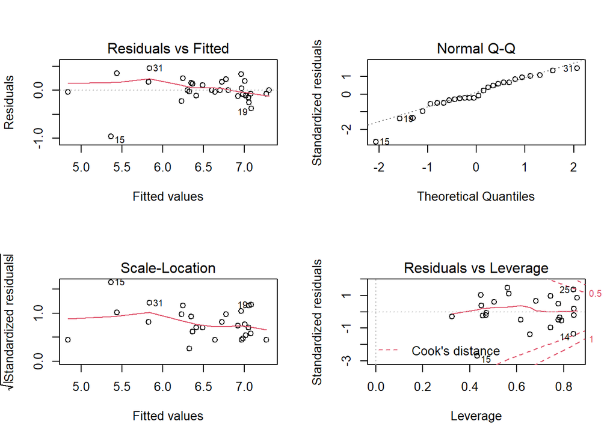

```r
par(mfrow = c(2,2))
plot(fit_OLS_drama_failure)
```

### 영화 데이터(성공)

#### 세부 factor에서 유의한 값

```r
fit_OLS_movie_success <- lm(All_rating ~ . , data=netflix_movie_success)
summary(fit_OLS_movie_success)
```

```
Call:
lm(formula = All_rating ~ ., data = netflix_movie_success)

Residuals:
     Min       1Q   Median       3Q      Max
-0.78537 -0.28013 -0.01161  0.25927  1.28153

Coefficients:
                     Estimate Std. Error t value Pr(>|t|)
(Intercept)          7.274756   0.446112  16.307  < 2e-16 ***
Mean_Length          0.001077   0.001110   0.971  0.33305
Director_max_award   0.002326   0.001143   2.034  0.04344 *
Year2014            -0.019238   0.473860  -0.041  0.96766
Year2015             0.252307   0.492156   0.513  0.60884
Year2016            -0.012930   0.458464  -0.028  0.97753
Year2017            -0.233411   0.447463  -0.522  0.60259
Year2018            -0.337181   0.443200  -0.761  0.44781
Year2019            -0.224737   0.441481  -0.509  0.61136
Year2020            -0.266661   0.446429  -0.597  0.55107
Lewdness높음         0.003127   0.149663   0.021  0.98336
Lewdness다소높음    -0.066954   0.097717  -0.685  0.49414
Lewdness보통         0.024585   0.100724   0.244  0.80746
Violence높음        -0.174014   0.143921  -1.209  0.22827
Violence다소높음     0.044996   0.099180   0.454  0.65062
Violence보통         0.025234   0.097967   0.258  0.79704
Profanity높음        0.169310   0.160008   1.058  0.29146
Profanity다소높음    0.050073   0.110400   0.454  0.65071
Profanity보통        0.118820   0.099558   1.193  0.23431
Fear높음             0.185262   0.161689   1.146  0.25345
Fear다소높음        -0.149704   0.126028  -1.188  0.23651
Fear보통            -0.164167   0.094248  -1.742  0.08330 .
Drugs높음            0.223762   0.158652   1.410  0.16021
Drugs다소높음       -0.038612   0.100530  -0.384  0.70139
Drugs보통           -0.091252   0.093736  -0.973  0.33166
Immatatable높음     -0.495526   0.155353  -3.190  0.00169 **
Immatatable다소높음 -0.250698   0.099621  -2.517  0.01276 *
Immatatable보통     -0.068312   0.104499  -0.654  0.51416
---
Signif. codes:  0 '***' 0.001 '**' 0.01 '*' 0.05 '.' 0.1 ' ' 1

Residual standard error: 0.4325 on 174 degrees of freedom
Multiple R-squared:  0.2025,    Adjusted R-squared:  0.07871
F-statistic: 1.636 on 27 and 174 DF,  p-value: 0.03217
```

### 유의한 factor

```r
anova(fit_OLS_movie_success)
```

```
Analysis of Variance Table

Response: All_rating
                    Df Sum Sq Mean Sq F value   Pr(>F)
Mean_Length          1  0.023 0.02345  0.1253 0.723740
Director_max_award   1  1.371 1.37075  7.3268 0.007470 **
Year                 7  2.249 0.32123  1.7170 0.107773
Lewdness             3  0.203 0.06779  0.3623 0.780281
Violence             3  0.409 0.13627  0.7284 0.536350
Profanity            3  0.432 0.14397  0.7695 0.512525
Fear                 3  0.938 0.31267  1.6712 0.174973
Drugs                3  0.290 0.09683  0.5176 0.670717
Immatatable          3  2.349 0.78286  4.1844 0.006868 **
Residuals          174 32.553 0.18709
---
Signif. codes:  0 '***' 0.001 '**' 0.01 '*' 0.05 '.' 0.1 ' ' 1
```

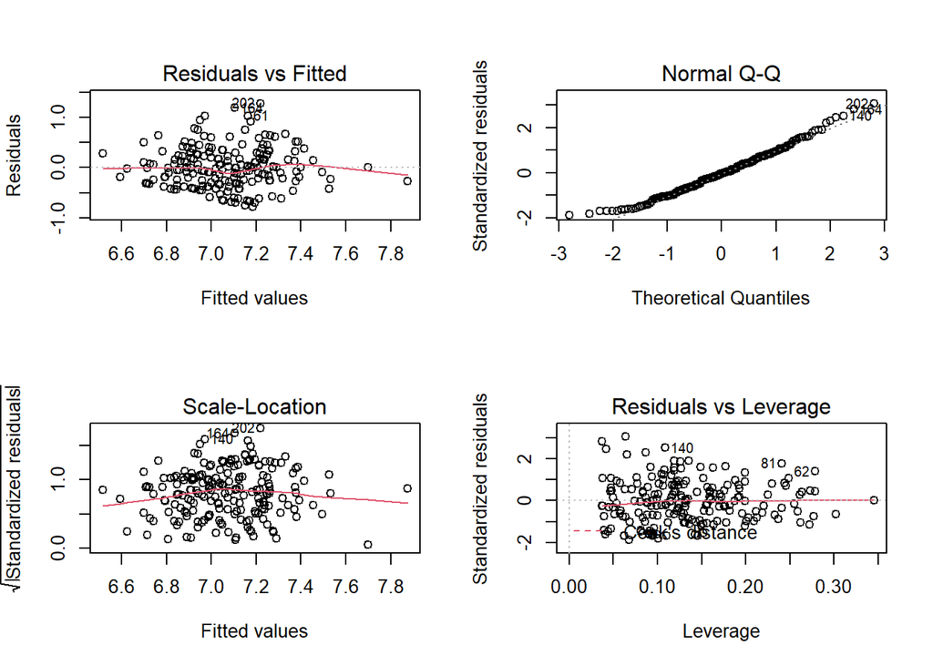

```r
par(mfrow = c(2,2))
plot(fit_OLS_movie_success)
```

### 영화 데이터(실패)

```r
fit_OLS_movie_failure <- lm(All_rating ~ . , data=netflix_movie_failure)
summary(fit_OLS_movie_failure)
```

```
Call:
lm(formula = All_rating ~ ., data = netflix_movie_failure)

Residuals:
     Min       1Q   Median       3Q      Max
-1.13418 -0.24981  0.03421  0.29859  0.95485

Coefficients:
                     Estimate Std. Error t value Pr(>|t|)
(Intercept)          5.326816   0.336371  15.836  < 2e-16 ***
Mean_Length          0.005944   0.001612   3.687 0.000312 ***
Director_max_award   0.006062   0.003395   1.785 0.076110 .
Year2016             0.150554   0.322607   0.467 0.641373
Year2017             0.039302   0.302945   0.130 0.896943
Year2018            -0.036843   0.299329  -0.123 0.902196
Year2019            -0.137136   0.301245  -0.455 0.649568
Year2020             0.076544   0.304687   0.251 0.801970
Lewdness높음        -0.043994   0.125583  -0.350 0.726565
Lewdness다소높음    -0.241769   0.102170  -2.366 0.019177 *
Lewdness보통        -0.165447   0.108483  -1.525 0.129234
Violence높음        -0.060332   0.148919  -0.405 0.685928
Violence다소높음    -0.133619   0.113696  -1.175 0.241671
Violence보통        -0.160813   0.103980  -1.547 0.123967
Profanity높음       -0.195784   0.151754  -1.290 0.198886
Profanity다소높음   -0.061640   0.137106  -0.450 0.653630
Profanity보통       -0.010787   0.133587  -0.081 0.935741
Fear높음             0.135821   0.173848   0.781 0.435816
Fear다소높음        -0.246107   0.128409  -1.917 0.057096 .
Fear보통            -0.157152   0.127884  -1.229 0.220951
Drugs높음            0.090690   0.160644   0.565 0.573188
Drugs다소높음        0.095275   0.119359   0.798 0.425941
Drugs보통            0.105616   0.108594   0.973 0.332253
Immatatable높음      0.140735   0.149819   0.939 0.348974
Immatatable다소높음  0.078377   0.119709   0.655 0.513595
Immatatable보통     -0.347249   0.134121  -2.589 0.010522 *
---
Signif. codes:  0 '***' 0.001 '**' 0.01 '*' 0.05 '.' 0.1 ' ' 1

Residual standard error: 0.4609 on 158 degrees of freedom
Multiple R-squared:  0.2798,    Adjusted R-squared:  0.1658
F-statistic: 2.455 on 25 and 158 DF,  p-value: 0.0004263
```

### 유의한 factor

```r
anova(fit_OLS_movie_failure)
```

```
Analysis of Variance Table

Response: All_rating
                    Df Sum Sq Mean Sq F value    Pr(>F)
Mean_Length          1  3.242  3.2423 15.2619 0.0001384 ***
Director_max_award   1  1.167  1.1670  5.4933 0.0203341 *
Year                 5  1.152  0.2303  1.0842 0.3712707
Lewdness             3  1.750  0.5834  2.7460 0.0448778 *
Violence             3  1.507  0.5022  2.3639 0.0732182 .
Profanity            3  0.118  0.0392  0.1846 0.9067317
Fear                 3  1.639  0.5463  2.5716 0.0561343 .
Drugs                3  0.327  0.1091  0.5134 0.6736420
Immatatable          3  2.137  0.7124  3.3534 0.0204985 *
Residuals          158 33.566  0.2124
---
Signif. codes:  0 '***' 0.001 '**' 0.01 '*' 0.05 '.' 0.1 ' ' 1
```

[figure not shown]

```r
par(mfrow = c(2,2))
plot(fit_OLS_movie_success)
```